# Baywheels Trip Data Exploration

## Preliminary Wrangling

> Baywheels Trip: Bay Area Motivate, LLC ("Motivate") operates the Bay Wheels bicycle sharing service. Motivate is committed to supporting bicycling as an alternative transportation option. Bikes are a fun and affordable way to get around. Baywheels Trip contains two types of bikes, docked bikes, and electric bikes. The services are being offered to Subscriber (Member ) or Customer (Casual).

```python
# import all packages and set plots to be embedded inline
import numpy as np
import pandas as pd
import matplotlib.pyplot as plt
import seaborn as sb

%matplotlib inline
```

```python
# load the dataset

baywheel = pd.read_csv('202005-baywheels-tripdata.csv')
baywheel.head(5)
```

|  | ride_id | rideable_type | started_at | ended_at | start_station_name | start_station_id | end_station_name | end_station_id | start_lat | start_lng | end_lat | end_lng | member_casual | is_equity |
| --- | --- | --- | --- | --- | --- | --- | --- | --- | --- | --- | --- | --- | --- | --- |
| 0 | BA4B4D93677877E8 | electric_bike | 2020-05-18 22:16:06 | 2020-05-18 22:28:20 | NaN | NaN | NaN | NaN | 37.3443 | -121.9218 | 37.3443 | -121.9217 | casual | False |
| 1 | 92634E825C7303CC | electric_bike | 2020-05-19 16:57:35 | 2020-05-19 17:29:56 | NaN | NaN | NaN | NaN | 37.7286 | -122.4921 | 37.7154 | -122.4854 | casual | False |
| 2 | 1FCDD14C62521CC1 | electric_bike | 2020-05-18 20:08:14 | 2020-05-18 20:14:25 | NaN | NaN | Webster St at Clay St | 492.0 | 37.7919 | -122.4174 | 37.7906 | -122.4325 | casual | False |
| 3 | 3A5CEC684CA9FA18 | electric_bike | 2020-05-19 14:05:08 | 2020-05-19 14:14:16 | NaN | NaN | NaN | NaN | 37.7557 | -122.4165 | 37.7681 | -122.4266 | casual | False |
| 4 | 1FF95A9C2D1ED7F8 | electric_bike | 2020-05-10 17:45:54 | 2020-05-10 18:29:29 | Pier 1/2 at The Embarcadero | 12.0 | NaN | NaN | 37.7964 | -122.3946 | 37.7780 | -122.4144 | casual | False |

```python
# the structure of dataset

print(baywheel.shape)
```

```
(138251, 14)
```

```python
# the dataset types

baywheel.info()
```

```
<class 'pandas.core.frame.DataFrame'>
RangeIndex: 138251 entries, 0 to 138250
Data columns (total 14 columns):
 #   Column              Non-Null Count   Dtype
---  ------              --------------   -----
 0   ride_id             138251 non-null  object
 1   rideable_type       138251 non-null  object
 2   started_at          138251 non-null  object
 3   ended_at            138251 non-null  object
 4   start_station_name  87315 non-null   object
 5   start_station_id    87315 non-null   float64
 6   end_station_name    84779 non-null   object
 7   end_station_id      84779 non-null   float64
 8   start_lat           138251 non-null  float64
 9   start_lng           138251 non-null  float64
 10  end_lat             138027 non-null  float64
 11  end_lng             138027 non-null  float64
 12  member_casual       138251 non-null  object
 13  is_equity           138251 non-null  bool
dtypes: bool(1), float64(6), object(7)
memory usage: 13.8+ MB
```

```python
# descriptive statistics for numeric variables

baywheel.describe()
```

|  | start_station_id | end_station_id | start_lat | start_lng | end_lat | end_lng |
| --- | --- | --- | --- | --- | --- | --- |
| count | 87315.000000 | 84779.000000 | 138251.000000 | 138251.000000 | 138027.000000 | 138027.000000 |
| mean | 227.397022 | 226.186567 | 37.722310 | -122.343617 | 37.722268 | -122.344021 |
| std | 170.232761 | 170.207720 | 0.151435 | 0.182993 | 0.151488 | 0.183225 |
| min | 3.000000 | 3.000000 | 37.239200 | -122.514300 | 37.004600 | -122.559000 |
| 25% | 74.000000 | 74.000000 | 37.760100 | -122.433700 | 37.760000 | -122.433800 |
| 50% | 177.000000 | 171.000000 | 37.773500 | -122.413200 | 37.773500 | -122.413200 |
| 75% | 386.000000 | 386.000000 | 37.787300 | -122.390400 | 37.787400 | -122.390600 |
| max | 521.000000 | 521.000000 | 37.880200 | -121.774600 | 37.962100 | -121.560600 |

```python
# types of bikes

baywheel['rideable_type'].value_counts()
```

```
electric_bike    94251
docked_bike      44000
Name: rideable_type, dtype: int64
```

```python
# types of customers

baywheel['member_casual'].value_counts()
```

```
casual    84519
member    53732
Name: member_casual, dtype: int64
```

```python
# check duplicated

baywheel['ride_id'].duplicated().value_counts()
```

```
False    138251
Name: ride_id, dtype: int64
```

```python
# creat copy of datast

baywheel_copy = baywheel.copy()
```

```python
# convert started_at and ended_at columns to datetime type

baywheel_copy['started_at'] = pd.to_datetime(baywheel_copy['started_at'])
baywheel_copy['ended_at']   = pd.to_datetime(baywheel_copy['ended_at'])
```

```python
# calculate the duration of the trip in minutes

t1 = pd.to_datetime(baywheel_copy['started_at'])
t2 = pd.to_datetime(baywheel_copy['ended_at'])
duration = []
for i in range(len(t1)):
    duration.append(pd.Timedelta(t2.loc[i] - t1.loc[i]).seconds / 60)

# creat trip duration column
baywheel_copy['trip_duration'] = duration
```

```python
# calculate the day of the week from started_at column

baywheel_copy['s_day_of_week'] = baywheel_copy.started_at.dt.strftime('%A')
```

```python
# calculate the day of the week from started_at column

baywheel_copy['start_hours'] = baywheel_copy.started_at.dt.strftime('%H')
```

```python
# check new columns

baywheel_copy.head(5)
```

|  | ride_id | rideable_type | started_at | ended_at | start_station_name | start_station_id | end_station_name | end_station_id | start_lat | start_lng | end_lat | end_lng | member_casual | is_equity | trip_duration | s_day_of_week | start_hours |
| --- | --- | --- | --- | --- | --- | --- | --- | --- | --- | --- | --- | --- | --- | --- | --- | --- | --- |
| 0 | BA4B4D93677877E8 | electric_bike | 2020-05-18 22:16:06 | 2020-05-18 22:28:20 | NaN | NaN | NaN | NaN | 37.3443 | -121.9218 | 37.3443 | -121.9217 | casual | False | 12.233333 | Monday | 22 |
| 1 | 92634E825C7303CC | electric_bike | 2020-05-19 16:57:35 | 2020-05-19 17:29:56 | NaN | NaN | NaN | NaN | 37.7286 | -122.4921 | 37.7154 | -122.4854 | casual | False | 32.350000 | Tuesday | 16 |
| 2 | 1FCDD14C62521CC1 | electric_bike | 2020-05-18 20:08:14 | 2020-05-18 20:14:25 | NaN | NaN | Webster St at Clay St | 492.0 | 37.7919 | -122.4174 | 37.7906 | -122.4325 | casual | False | 6.183333 | Monday | 20 |
| 3 | 3A5CEC684CA9FA18 | electric_bike | 2020-05-19 14:05:08 | 2020-05-19 14:14:16 | NaN | NaN | NaN | NaN | 37.7557 | -122.4165 | 37.7681 | -122.4266 | casual | False | 9.133333 | Tuesday | 14 |
| 4 | 1FF95A9C2D1ED7F8 | electric_bike | 2020-05-10 17:45:54 | 2020-05-10 18:29:29 | Pier 1/2 at The Embarcadero | 12.0 | NaN | NaN | 37.7964 | -122.3946 | 37.7780 | -122.4144 | casual | False | 43.583333 | Sunday | 17 |

### What is the structure of your dataset?

> 138251 rows and 14 columns.

### What is/are the main feature(s) of interest in your dataset?

> I want to know what is the most factors that affect the duration of the trip, so I will calculate the trip duration, and I want to know what is the days and time where users take a long duration trip, so I will convert the date to the day of the week and extract the start hours from the dataset.

### What features in the dataset do you think will help support your investigation into your feature(s) of interest?

> Bikes type, the start and end date and time, and types of members.

## Univariate Exploration

> I will check the most factors I think to affect in trip duration.

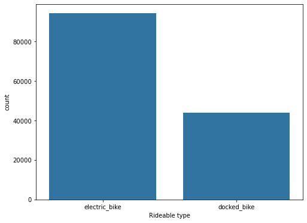

```python
# univariate plots of rideable_type

plt.figure(figsize = [8, 6])
base_colore = sb.color_palette()[0]
sb.countplot(data = baywheel_copy, x = 'rideable_type', color = base_colore);
plt.xlabel('Rideable type');
```

> There are two types of bikes in this dataset, docked bikes, and electric bikes, I observed the electric bikes are more than docked bikes.

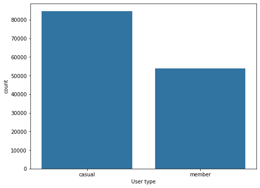

```python
# univariate plots of member_casual

plt.figure(figsize = [8, 6])
base_colore = sb.color_palette()[0]
sb.countplot(data = baywheel_copy, x = 'member_casual', color = base_colore);
plt.xlabel('User type');
```

> There are two types of members in this dataset, Member (subscriber) and casual (customer), I noticed that the customers are more than Members.

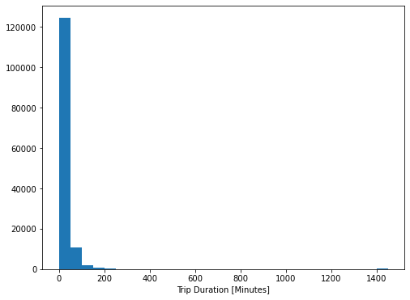

```python
# univariate plots of trip_duration

plt.figure(figsize = [8, 6])
bin_edges = np.arange(0, baywheel_copy['trip_duration'].max()+50, 50)
plt.hist(data = baywheel_copy, x = 'trip_duration', bins = bin_edges);
plt.xlabel('Trip Duration [Minutes]');
```

> Most of the trip duration between 0 and 90 minutes, there are few trips that have very large tripe duration.

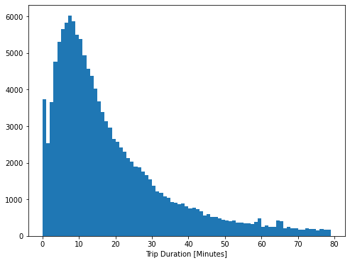

```python
# Histogram of trip_duration

plt.figure(figsize = [8, 6])
bins = np.arange(0, 80, 1)
plt.hist(data=baywheel_copy, x='trip_duration', bins=bins);
plt.xlabel('Trip Duration [Minutes]');
```

> I plot the histogram for the trip duration between 0 and 80 minutes, where it right-skewed.

```python
# filter all trip duration larger than 80 minutes

baywheel_copy = baywheel_copy.query('trip_duration <= 80')
```

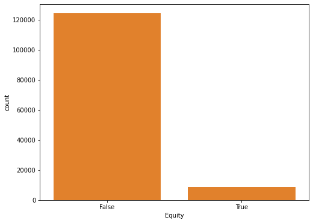

```python
# univariate plots of is_equity

plt.figure(figsize = [8, 6])
base_colore = sb.color_palette()[1]
sb.countplot(data = baywheel_copy, x = 'is_equity', color = base_colore);
plt.xlabel('Equity');
```

> I notice that most of the members are not equity.

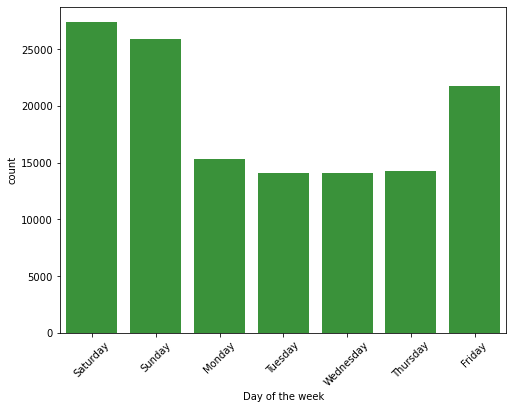

```python
# trip distribution over weekdays

days = ['Saturday', 'Sunday', 'Monday', 'Tuesday', 'Wednesday', 'Thursday', 'Friday']
weekdaycat = pd.api.types.CategoricalDtype(ordered=True, categories=days)
baywheel_copy['s_day_of_week'] = baywheel_copy['s_day_of_week'].astype(weekdaycat)

base_colore = sb.color_palette()[2]
plt.figure(figsize = [8, 6])
plt.xticks(rotation=45);
sb.countplot(data = baywheel_copy, x = 's_day_of_week', color = base_colore);
plt.xlabel('Day of the week');
```

> The days that have most trips are Saturday, Sunday, Friday, and Monday respectively. The rest of the weekday almost has the same trips.

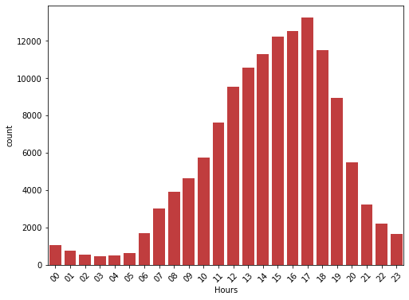

```python
# trip distribution over day hours

base_colore = sb.color_palette()[3]
plt.figure(figsize = [8, 6])
plt.xticks(rotation=45);
sb.countplot(data = baywheel_copy, x = 'start_hours', color = base_colore);
plt.xlabel('Hours');
```

> The most of trips in between 9 and 20 o'clock in most days.

### Discuss the distribution(s) of your variable(s) of interest. Were there any unusual points? Did you need to perform any transformations?

> The days that have most trips are Saturday, Sunday, and Friday. Most of the trip duration between 0 and 20 minutes, there are few trips that have very large tripe duration. The most of trips in between 9 and 20 o'clock in most days.

### Of the features you investigated, were there any unusual distributions? Did you perform any operations on the data to tidy, adjust, or change the form of the data? If so, why did you do this?

> I convert started_at and ended_at columns to DateTime type, then I calculate the duration of the trip in minutes, convert the date to the day of the week and extract the start hours from the dataset. I make this for know the relation between the trip duration and other factors.

## Bivariate Exploration

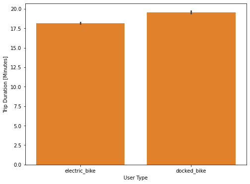

```python
# Bivariate plots of rideable_type and trip_duration

plt.figure(figsize = [8, 6]);
sb.barplot(data = baywheel_copy, x = 'rideable_type', y = 'trip_duration',color = sb.color_palette()[1]);
plt.xlabel('User Type');
plt.ylabel('Trip Duration [Minutes]');
```

> The relation between the trip duration and rideable type.

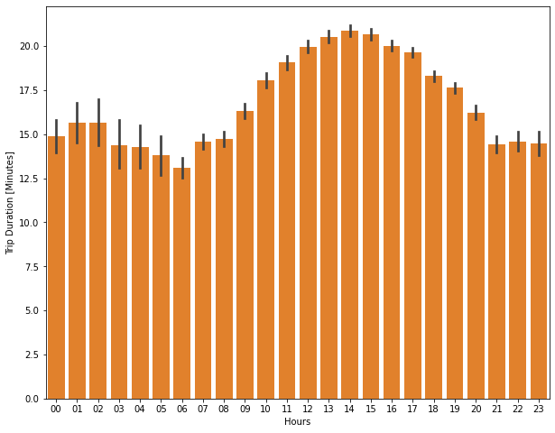

```python
# Bivariate plots of start_hours and trip_duration

plt.figure(figsize = [10, 8]);
sb.barplot(data = baywheel_copy, x = 'start_hours', y = 'trip_duration',color = sb.color_palette()[1]);
plt.xlabel('Hours');
plt.ylabel('Trip Duration [Minutes]');
```

> The relation between the trip duration and trip start hour.

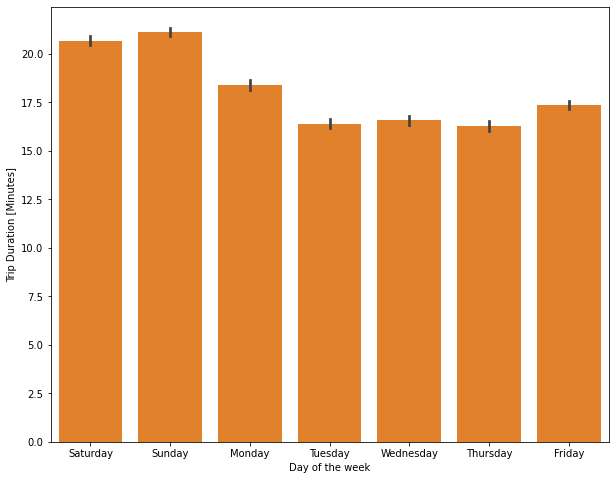

```python
# Bivariate plots of s_day_of_week and trip_duration

plt.figure(figsize = [10, 8]);
sb.barplot(data = baywheel_copy, x = 's_day_of_week', y = 'trip_duration',color = sb.color_palette()[1]);
plt.xlabel('Day of the week');
plt.ylabel('Trip Duration [Minutes]');
```

> The relation between the trip duration and trip day of the week.

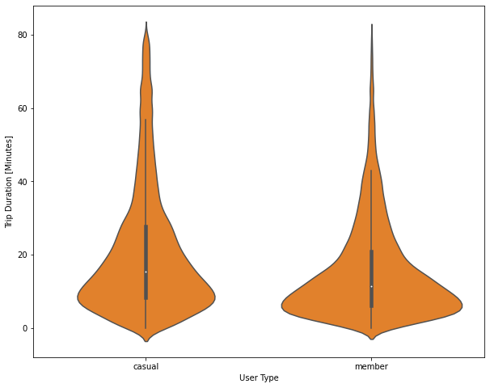

```python
# Bivariate plots of member_casual and trip_duration

plt.figure(figsize = [10, 8]);
sb.violinplot(data = baywheel_copy, x = 'member_casual', y = 'trip_duration',color = sb.color_palette()[1]);
plt.xlabel('User Type');
plt.ylabel('Trip Duration [Minutes]');
```

> The relation between the trip duration and types of members.

### Did you observe any interesting relationships between the other features (not the main feature(s) of interest)?

> No

## Multivariate Exploration

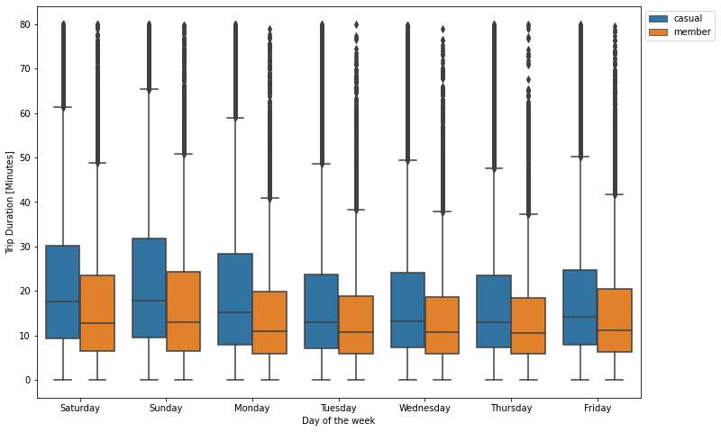

```python
# multivariate plot of s_day_of_week by trip_duration weight, and member_casual

plt.figure(figsize=(12,8))
sb.boxplot(data = baywheel_copy, x = 's_day_of_week', y = 'trip_duration', hue = 'member_casual');
plt.legend(loc = 2, bbox_to_anchor = (1.0, 1.0)) ;
plt.xlabel('Day of the week');
plt.ylabel('Trip Duration [Minutes]');
```

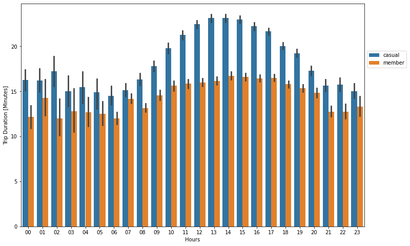

```python
# multivariate plot of start_hours by trip_duration weight, and member_casual

plt.figure(figsize=(12,8))
ax = sb.barplot(data = baywheel_copy, x = 'start_hours', y = 'trip_duration', hue = 'member_casual')
ax.legend(loc = 8, ncol = 3, framealpha = 1)
plt.legend(loc = 2, bbox_to_anchor = (1.0, 0.8)) ;
plt.xlabel('Hours');
plt.ylabel('Trip Duration [Minutes]');
```

### Talk about some of the relationships you observed in this part of the investigation. Were there features that strengthened each other in terms of looking at your feature(s) of interest?

> In general the casual (customer) has trip duration more than Member (subscriber) in all days and all hours.

### Were there any interesting or surprising interactions between features?

> Yes